# Time Series Project

### Problem Statement

In food retail forecast plays a big role in retail, getting it right will ensure you have the right availability and minimal waste. Getting it wrong will result in shortages or potentially high waste either one will reduce profit.

So, it’s quite valuable to be able to have insight on the trend history and how the market is changing to be able to prepare for the future.

Some of the interesting products we have in foods are seasonal performing lines, its vital to get the forecast right as any major over or under predictions could adversely affect the success of the season. We will be looking to model the forecast of the seasonally performing product group burgers. We will look at the data at weekly level to predict future trends and highlighting peaking periods. We will also further include weather in our model to make it multivariate model.

Time series is a great method to tackle this question as it helps us understand the past and help predict the future. We can reveal patterns by plotting data against time as we have one data point for every time period and each time period is equally spaced from each other. Hopefully this would predict the trend and seasonal pattern.

My initial expectations are sales in the burgers product group to increase when weather is hot with sunshine and around major sporting events. I also expect the sales to drop when the weather is cold and rainy.

### Hypothesis

Null hypothesis:

1- There is a visible trend or seasonal pattern.

2- Is the visible seasonal pattern in shape with weather.

Alternative hypothesis:

1-There is no visible trend or seasonal pattern

2- There is no shape between the seasonal and weather pattern.

### Overview

The initial plan for the project is as follows:

1. Source the data
2. Explore & clean the data
3. Prepare the data for analysis
4. Analyse the data
5. Evaluate the model
6. Improve the model

### Source the data

The data was sourced from our Enterprise analytics hub using sql and exported as a csv. The data is for the last 3 years at daily level but was aggregated up to super product group level from product level. Weather data was also collected for the same period and then joined to the original data set. Initial thoughts about potential issues:

- Our data will be able to show the peak and troughs in sales and weather, and potentially explain the troughs with peaking weather. I feel our issue will arise when sales are explained by external events outside our model like events that could likely cause a peak in sales which wouldn’t be explained by our model.

In terms of sharing issues, we don’t have much sensitive data, only sales quantity. The rest of the data is public such as calendar and weather.

### Explore & clean the data

Initially the idea was to explore, clean and then prepare the data but due to issue while exploring It was decided to merge the exploring and the cleaning process into one.

```python
# import necessary packages for data exploration and analysis
import pandas as pd
import numpy as np
import matplotlib.pylab as plt
#%matplotlib inline
from math import sqrt
from datetime import datetime, timedelta
from statsmodels.tsa.seasonal import seasonal_decompose
from statsmodels.graphics.tsaplots import plot_acf, plot_pacf
import statsmodels.api as sm
from statsmodels.tsa.statespace.sarimax import SARIMAX
import warnings
warnings.filterwarnings("ignore")
```

```python
# load the data from a csv file into a data frame
d = pd.read_csv(r"C:\Users\c2345091\Documents\TimeSeries\hackathon_data.csv",encoding='cp1252',)
# look at the first 5 rows of data
d.head()
```

|  | wkend | gross_sales_qty | weather_date | avg(daymin) | avg(dayminfl) | avg(daymax) | avg(daymaxfl) | avg(sun) | avg(sunprob) | avg(snow) | avg(snowprob) | avg(precip) | avg(precipprob) |
| --- | --- | --- | --- | --- | --- | --- | --- | --- | --- | --- | --- | --- | --- |
| 0 | 09/04/2016 00:00 | 116.0 | 03/04/2016 00:00 | 7.00 | 5.44 | 15.94 | 14.00 | 0.0 | 12.16 | 0.0 | 0.00 | 0.16 | 56.83 |
| 1 | 09/04/2016 00:00 | 136.0 | 04/04/2016 00:00 | 8.55 | 7.00 | 12.00 | 10.00 | 0.0 | 49.38 | 0.0 | 4.77 | 0.00 | 55.66 |
| 2 | 09/04/2016 00:00 | 163.0 | 05/04/2016 00:00 | 7.22 | 5.22 | 14.72 | 11.94 | 0.5 | 31.22 | 0.0 | 2.83 | 0.00 | 3.55 |
| 3 | 09/04/2016 00:00 | 132.0 | 06/04/2016 00:00 | 6.72 | 4.33 | 11.94 | 8.94 | 0.0 | 80.33 | 0.0 | 4.77 | 0.00 | 51.33 |
| 4 | 09/04/2016 00:00 | 164.0 | 07/04/2016 00:00 | 5.50 | 1.00 | 10.61 | 8.61 | 0.0 | 36.38 | 0.0 | 20.05 | 0.83 | 75.38 |

```python
# gather basic information about the dataset
print(f"Rows: {d.shape[0]}\nColumns: {d.shape[1]}")
```

```
Rows: 1360
Columns: 13
```

```python
# display information about the data table
d.info()
```

```
<class 'pandas.core.frame.DataFrame'>
RangeIndex: 1360 entries, 0 to 1359
Data columns (total 13 columns):
wkend              1360 non-null object
gross_sales_qty    1357 non-null float64
weather_date       1360 non-null object
avg(daymin)        1360 non-null float64
avg(dayminfl)      1360 non-null float64
avg(daymax)        1359 non-null float64
avg(daymaxfl)      1360 non-null float64
avg(sun)           1360 non-null float64
avg(sunprob)       947 non-null float64
avg(snow)          1360 non-null float64
avg(snowprob)      947 non-null float64
avg(precip)        1360 non-null float64
avg(precipprob)    947 non-null float64
dtypes: float64(11), object(2)
memory usage: 138.2+ KB
```

```python
# check if there are any null values
d.isnull().values.any()
```

```
True
```

```python
# counting the null values
d.isna().sum()
```

```
wkend                0
gross_sales_qty      3
weather_date         0
avg(daymin)          0
avg(dayminfl)        0
avg(daymax)          1
avg(daymaxfl)        0
avg(sun)             0
avg(sunprob)       413
avg(snow)            0
avg(snowprob)      413
avg(precip)          0
avg(precipprob)    413
dtype: int64
```

Data was loaded successfully and basic information about the data has now been established. We can clearly see a lot of null values which means the data set will need to be cleaned. Looking closely we can also see that some data types will also need to be changed.

```python
# rename a specific column
d=d.rename(columns = {"avg(daymax)":'temp'})
```

I’ve gone ahead and renamed the above column as its not in a friendly format and will cause me issues later in the project.

The next step is to create a subset of the data with only the columns we require for the analysis.

```python
# create a new data frame with selected columns
nd = d[["wkend","weather_date", "gross_sales_qty"]]
# view the data table
nd.head(5)
```

|  | wkend | weather_date | gross_sales_qty |
| --- | --- | --- | --- |
| 0 | 09/04/2016 00:00 | 03/04/2016 00:00 | 116.0 |
| 1 | 09/04/2016 00:00 | 04/04/2016 00:00 | 136.0 |
| 2 | 09/04/2016 00:00 | 05/04/2016 00:00 | 163.0 |
| 3 | 09/04/2016 00:00 | 06/04/2016 00:00 | 132.0 |
| 4 | 09/04/2016 00:00 | 07/04/2016 00:00 | 164.0 |

```python
# Group by wkend to sum the sales quantity
nd = nd.groupby(['wkend'], as_index=False, sort=False)[["gross_sales_qty"]].sum()
# Show first 5 rows to check previous code
nd.head(5)
```

|  | wkend | gross_sales_qty |
| --- | --- | --- |
| 0 | 09/04/2016 00:00 | 1162.0 |
| 1 | 16/04/2016 00:00 | 1533.0 |
| 2 | 23/04/2016 00:00 | 1668.0 |
| 3 | 30/04/2016 00:00 | 1647.0 |
| 4 | 07/05/2016 00:00 | 2307.0 |

We aggregated the data up to weekly level using a group by function as daily level for the past 3 years may affect the performance of the model later.

```python
# checking the null values after previous codes
nd.isna().sum()
```

```
wkend              0
gross_sales_qty    0
dtype: int64
```

For time series we require our date column to be in a date time format so we need to convert the format.

```python
# change format
nd['wkend'] = pd.to_datetime(nd['wkend'], format="%d/%m/%Y %H:%M")
nd.set_index('wkend', inplace = True)
```

```python
# display information about the data table
nd.info()
```

```
<class 'pandas.core.frame.DataFrame'>
DatetimeIndex: 196 entries, 2016-04-09 to 2020-01-04
Data columns (total 1 columns):
gross_sales_qty    196 non-null float64
dtypes: float64(1)
memory usage: 3.1 KB
```

```python
# check the first 5 rows of the dataset
nd.head()
```

| wkend | gross_sales_qty |
| --- | --- |
| 2016-04-09 | 1162.0 |
| 2016-04-16 | 1533.0 |
| 2016-04-23 | 1668.0 |
| 2016-04-30 | 1647.0 |
| 2016-05-07 | 2307.0 |

Now we have our final data set ready, a data time column with our weekending data and the second column is our sales quantity. We are now ready to create a time series dataset.

```python
# creating our time series dataset
ts = nd['gross_sales_qty']
```

```python
# checking type
type(ts)
```

```
pandas.core.series.Series
```

```python
# gather basic statistical information about the gross_sales_qty variable
ts.describe()
```

```
count     196.000000
mean     1215.790816
std       519.912154
min       134.000000
25%       817.500000
50%      1182.000000
75%      1593.000000
max      2660.000000
Name: gross_sales_qty, dtype: float64
```

Now let’s look at visualising the data so we can get a more complete view of our dataset.

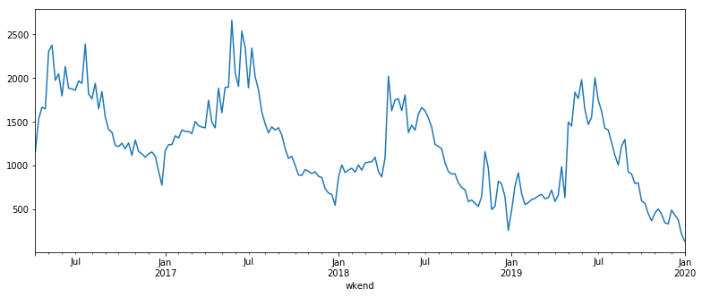

```python
# plot line graph of our dataset
plt.figure(figsize=(13,5))
plt.figure(1)
ts.plot()
```

We can clearly see there is a clear seasonal pattern every year with peaks around July and troughs around January.

### Prepare the data

#### Decomposition

Time series is built up of components that can be categorised into systemic or non-systemic components where the former has consistency or occurrence and can be modelled and the later cannot be modelled. Systemic components are trend and seasonality and non-systemic component is noise. Time series can be combined by adding these three components to create an additive time series or multiplied to create a multiplicative time series. Multiplicative time series can be transformed to an additive by taking the log.

Decomposition is the process of deconstructing the three components trend, seasonality and noise.

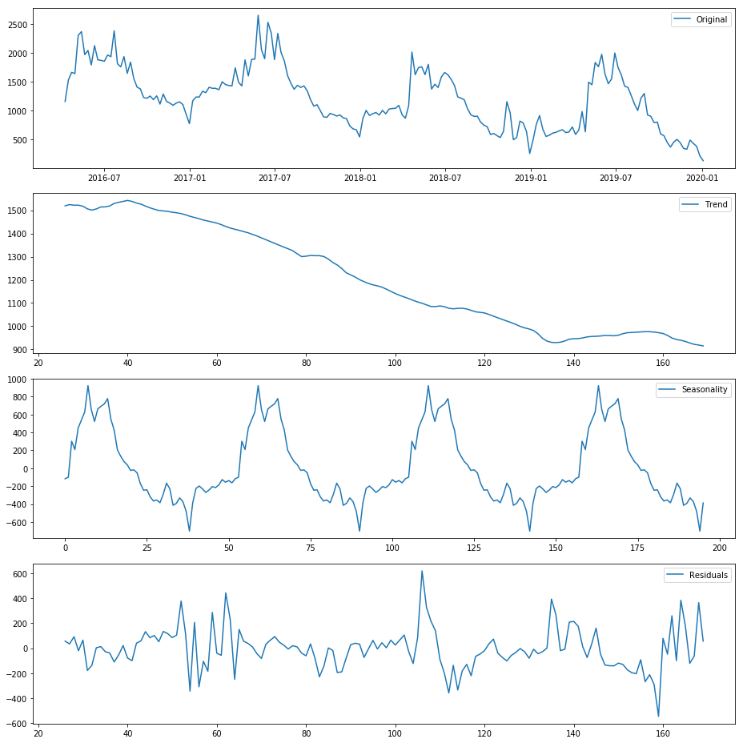

```python
# import necessary packages for data exploration and analysis
from statsmodels.tsa.seasonal import seasonal_decompose
#decomposition = seasonal_decompose(ts, model='additive',freq=52)
decomposition = seasonal_decompose(ts.values,freq=52)

trend = decomposition.trend
seasonal = decomposition.seasonal
residual = decomposition.resid

plt.figure(figsize=(13,13))
plt.figure(1)
plt.subplot(411)
plt.plot(ts, label = 'Original')
plt.legend(loc = 'best')
plt.subplot(412)
plt.plot(trend, label = 'Trend')
plt.legend(loc = 'best')
plt.subplot(413)
plt.plot(seasonal, label = 'Seasonality')
plt.legend(loc = 'best')
plt.subplot(414)
plt.plot(residual, label = 'Residuals')
plt.legend(loc = 'best')
plt.tight_layout()
```

From the decomposition we can clearly see a very nice seasonality pattern that has been extracted. We can also see a clear downward trend and in terms of noise we see an interesting pattern, wherever the original line doesn’t follow the seasonality trend the noise is more apparent.

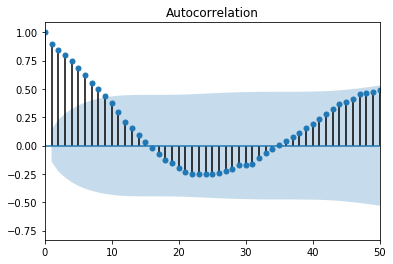

```python
# plot auto correlation function which plots lags on the horizontal and the correlations on vertical axis.
plot_acf(ts)
plt.xlim(0,50)
plt.show()
```

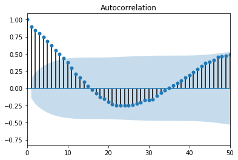

```python
# plot auto correlation function
plot_acf(ts.dropna())
plt.xlim(0,50)
plt.show()
```

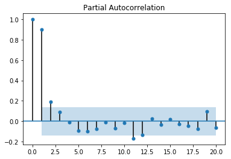

```python
# plot the partial autocorrelation
plot_pacf(ts.dropna(), lags=20)
plt.show()
```

#### Model and transform

Before we run our model, we need to confirm if our data is stationary, which means that over time the mean should be constant, covariance or standard deviation should be constant, or auto-covariance should not depend on time. Trend and seasonality are the two components that cause time series to not be stationary. If a model is stationary that means its behaviour over a time interval may repeat again, which helps forecast accurately.

To test for stationarity, we can run a simple KPSS test. This test assumes a null hypothesis that a time series is stationary. That means, if the p-value of the test is less than 0.05, we can reject this hypothesis and assume the data is not stationary.

```python
# import necessary packages for data exploration and analysis
from statsmodels.tsa.stattools import kpss
# run kpss test on dataset
kpss(ts)
```

```
(0.6086854176860684,
 0.02184678021035741,
 15,
 {'10%': 0.347, '5%': 0.463, '2.5%': 0.574, '1%': 0.739})
```

In this case, our p-value is less than 0.05, meaning we should reject the null hypothesis. Our data is not stationary.

We need to do some transformations to make our data stationary. Let's remember what it looks like.

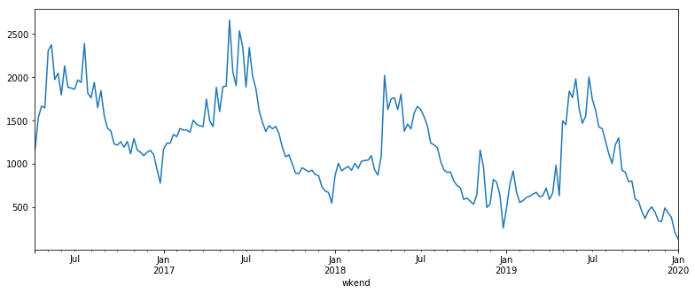

```python
# plot original dataset
plt.figure(figsize=(13,5))
plt.figure(1)
ts.plot()
```

A common way to remove this changing variance is to take the natural log of all of the values in our dataset.

```python
# taking the log of our dataset
ts_log = np.log(ts)
```

```python
# run kpss test again
kpss(ts_log.dropna())
```

```
(0.6832509553986374,
 0.01506809496376023,
 15,
 {'10%': 0.347, '5%': 0.463, '2.5%': 0.574, '1%': 0.739})
```

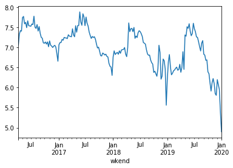

```python
ts_log.plot()
```

We can see that our P-value is still less than 0.05 so our data is still not stationary, but we can see from the graph that taking the log has reduced the difference between the highest peaks and the lowest peaks. We still need to make our data stationary and one way we can do that is by differencing our data. This simply means we create a new time series that is made up of the difference between the values of our existing dataset.

```python
# taking the difference
ts_log.diff().dropna().head()
```

```
wkend
2016-04-16    0.277084
2016-04-23    0.084399
2016-04-30   -0.012670
2016-05-07    0.336993
2016-05-14    0.029470
Name: gross_sales_qty, dtype: float64
```

```python
# running the kpss test
kpss(ts_log.diff().dropna())
```

```
(0.21515109357638987,
 0.1,
 15,
 {'10%': 0.347, '5%': 0.463, '2.5%': 0.574, '1%': 0.739})
```

Now our p-value is greater than 0.05 which means our data is now stationary.

Now we can replot our autocorrelations graphs to determine the parameters p, d and q. Our parameters are determined by how many data points from 0 are outside the significance level (blue block).

[figure not shown]

```python
# plot auto correlation function
plot_acf(ts_log.diff())
plt.xlim(0,50)
plt.show()
```

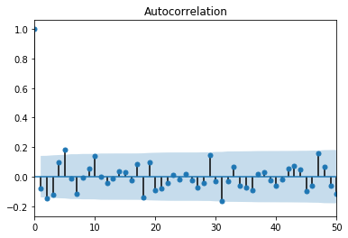

```python
# plot auto correlation function
plot_acf(ts_log.diff().dropna())
plt.xlim(0,50)
plt.show()
```

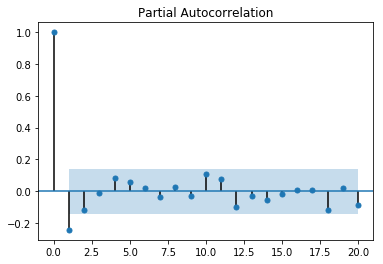

```python
# plot the partial autocorrelation
plot_pacf(ts.diff().dropna(), lags=20)
plt.show()
```

```python
ts_diff = ts.diff().dropna()
```

### Analyse the Data

ARIMA model

ARIMA stands for an AutoRegressive Integrated Moving Average Model. It explicitly serves a group of standard structures in time series data providing a simple and powerful method for making skilful time series forecasts. There are three aspects of the model:

1. Autoregression. A model that uses the dependent relationship between an observation and some number of lagged observations.
2. Integrated. The use of differencing of raw observations in order to make the time series stationary.
3. Moving Average. A model that uses the dependency between an observation and a residual error from a moving average model applied to lagged observations. Each of these components are explicitly specified in the model as a parameter. A standard notation is used of ARIMA(p,d,q) where the parameters are substituted with integer values to quickly indicate the specific ARIMA model being used.

The ARIMA parameters:

1. p: The number of lag observations included in the model, also called the lag order.
2. d: The number of times that the raw observations are differenced, also called the degree of differencing.
3. q: The size of the moving average window, also called the order of moving average.

```python
# importing relevant libraries
from sklearn.metrics import mean_squared_error
from statsmodels.tsa.arima_model import ARIMA
```

```python
# This method finds the MSE of a single ARIMA model.
def evaluate_arima_model(nd, arima_order):
    split=int(len(nd) * 0.8) # Needs to be an integer because it is later used as an index.
    train, test = nd[0:split], nd[split:len(nd)]
    past=[x for x in train]
    # make predictions
    predictions = list()
    for i in range(len(test)):#timestep-wise comparison between test data and one-step prediction ARIMA model.
        model = ARIMA(past, order=arima_order)
        model_fit = model.fit(disp=0)
        future = model_fit.forecast()[0]
        predictions.append(future)
        past.append(test[i])
    # calculate out of sample error
    error = mean_squared_error(test, predictions)
    return error
```

```python
# This method evaluates ARIMA models with several different p, d, and q values.
def evaluate_models(dataset, p_values, d_values, q_values):
    best_score, best_cfg = float("inf"), None
    for p in p_values:
        for d in d_values:
            for q in q_values:
                order = (p,d,q)
                try:
                    mse = evaluate_arima_model(dataset, order)
                    if mse < best_score:
                        best_score, best_cfg = mse, order
                    print('ARIMA%s MSE=%.3f' % (order,mse))
                except:
                    continue
    return print('Best ARIMA%s MSE=%.3f' % (best_cfg, best_score))
```

```python
# Now, we choose a couple of values to try for each parameter.
p_values = [x for x in range(0, 3)]
d_values = [x for x in range(0, 3)]
q_values = [x for x in range(0, 3)]
```

```python
# Finally, we find the best ARIMA model for our data.
#this can take a while to execute.
#import warnings #warnings.filterwarnings("ignore")
#evaluate_models(ts_log, p_values, d_values, q_values)
```

```python
p=0
d=2
q=1
model = ARIMA(ts_diff, order=(p,d,q))
model_fit = model.fit()
forecast = model_fit.forecast(52)
```

```python
model_fit.summary()
```

ARIMA Model Results

| Dep. Variable: | D2.gross_sales_qty | No. Observations: | 193 |
| --- | --- | --- | --- |
| Model: | ARIMA(0, 2, 1) | Log Likelihood | -1407.776 |
| Method: | css-mle | S.D. of innovations | 351.290 |
| Date: | Tue, 11 Feb 2020 | AIC | 2821.552 |
| Time: | 14:44:45 | BIC | 2831.340 |
| Sample: | 04-30-2016 | HQIC | 2825.516 |
|  | - 01-04-2020 |  |  |

|  | coef | std err | z | P>\|z\| | [0.025 | 0.975] |
| --- | --- | --- | --- | --- | --- | --- |
| const | 0.0478 | 0.450 | 0.106 | 0.916 | -0.835 | 0.931 |
| ma.L1.D2.gross_sales_qty | -1.0000 | 0.013 | -78.511 | 0.000 | -1.025 | -0.975 |

Roots

|  | Real | Imaginary | Modulus | Frequency |
| --- | --- | --- | --- | --- |
| MA.1 | 1.0000 | +0.0000j | 1.0000 | 0.0000 |

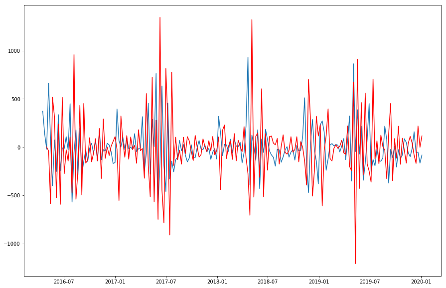

```python
# plot model
plt.figure(figsize=(15,10))
plt.plot(ts_diff)
plt.plot(model_fit.predict(), color = 'red')
```

#### Forecasting

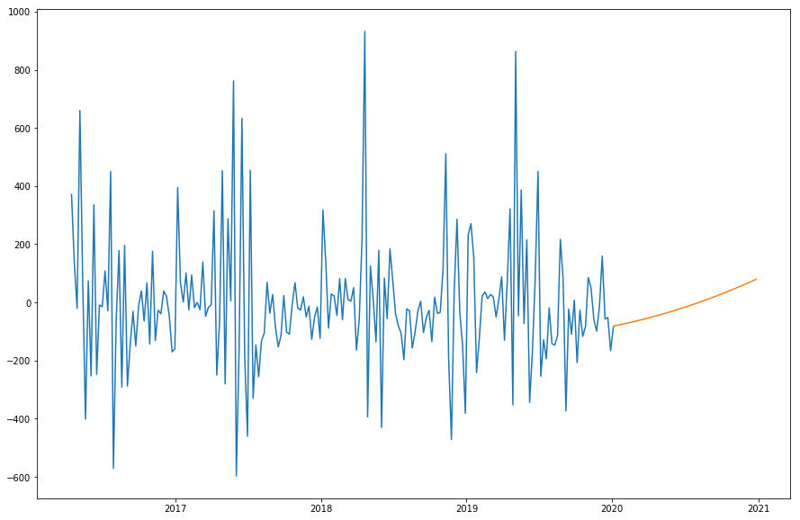

```python
# Set a variable with the amount of months to forecast
periods_to_forecast = 52

# Create a range of future dates that is the length of the periods we will forecast
date_range = pd.date_range(ts.index[-1], periods = periods_to_forecast,
              freq='W').strftime("%Y-%m-%d").tolist()

# Turn range into a dataframe that includes predictions
future_months = pd.DataFrame(date_range, columns = ['Month'])
future_months['Month'] = pd.to_datetime(future_months['Month'])
future_months.set_index('Month', inplace = True)
future_months['Prediction'] = forecast[0]

# Plot future predictions
plt.figure(figsize=(15,10))
plt.plot(ts_diff)
plt.plot(ts_diff['2020-01'].append(future_months['Prediction']))
plt.show()
```

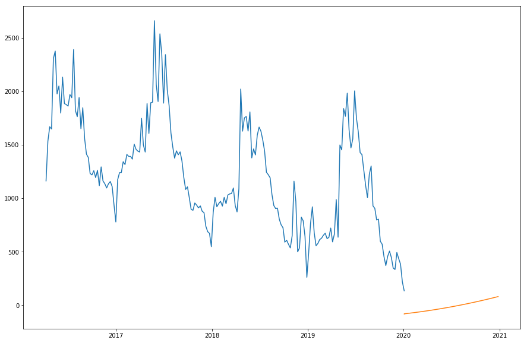

```python
# plot your future predictions against original plot
plt.figure(figsize=(15,10))
plt.plot(ts)
plt.plot(ts_diff['2020-01'].append(future_months['Prediction']))
plt.show()
```

### Evaluate the model

We have looked at the sales of burgers from April 2016 until the current date to build a model that will predict sales for the next year. Looking at our data we can see we have a strong seasonality with peaks in summer and troughs in winter with an overall downwards trend.

We can clearly see that the ARIMA model is not fit to predict our data due to the core attribute of seasonality. We must look at a different model.